# Кластеризация

# Постановка задачи

Кластеризация - она же (unsupervisited classification or clusterization) - задача обучения без учителя, при котором исследователь имея набор объектов выделяет среди них группы имеющие в той или иной мере сходства.

Заранее неизвестна информация принадлежности к классам (кластерам), информация об количестве классов (кластеров). Именно по этой причине данная задача относится к группе задач обучения без учителя.

Если при постановке задачи, возможно собрать информацию о принадлежности объектам к тем или иным кластерам, то предпочительнее решать задачу классификации, имеющую лучшую точность

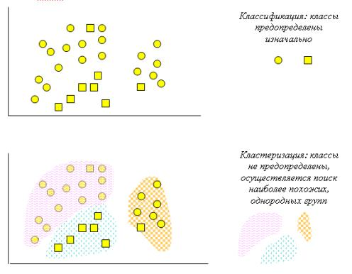

[figure not shown]

Примером в нашей компании могут послужить следующие задачи:

1. Разделение филиалов магазинов по нагрузке протекающих процессов и выделение общих групп для выстраивания схожих систем управления
2. Выделение групп покупателей, с различным набором характеристик (платёжная способность, покупка схожих товаров ...)

# Методы решения

## K-means - метод K средних

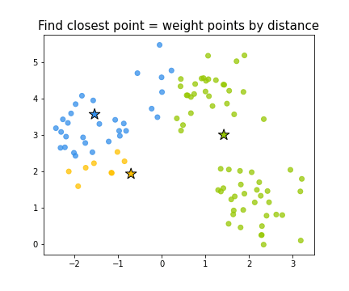

[figure not shown]

Пусть имеется множество $X$ - множество объектов подлежащих кластеризации.

Зададим параметр $k$ - являющийся количеством предполагаемых кластеров. Тогда получим $K_c$ - множество центров кластеров. Тогда алгоритм k-средних примет следующий вид:

1. Зададим в начальный момент времени случайным образом положение центров кластеров.
2. Рассчитаем для каждого объекта из множества $X$ расстояние от центра кластера до выбранного объекта
3. Распределим все $x \in X$ к кластерам (i), так что для каждого объекта выполнится $|x,K_c^i| \rightarrow min $
4. Из принадлежности объектов к кластерам, рассчитаем новое значение для каждого центра кластера из $K_c$ как среднее арифметическое всех векторов объектов вошедших в кластер
5. Если хотя бы один центр кластера изменился, то перейдем к шагу 1. Если центры кластеров остались неизменны алгоритм прекращает работу

**Улучшения алгоритма**

Улучшения алгоритма доступно в момент выбора начального положения центров кластеров, а именно:

1. Выбирать начальное положение центра первого из объектов - предотвращение выбора положений равноудаленных от всех кластеров.
2. Выбор последующих (2+) центров кластеров наиболее удалённых от первого. $p(s) \cdot \varrho{(x_{next}, x_1})^2$ - где $x_{next}$ - последующий центр кластера, $x_1$ - центр выбранный на шаге 1, $p(s)$ - вероятность выбора точки - *K-means ++*

**mini batch kmeans**

Такой же алгоритм но при этом на каждом шаге расчёт производится на некоторой выборке

**Метрики**

При решении задачи кластеризации оптимизируется Евклидово расстояние от центра до точек нашего множества.

В случае решения задачи кластеризации текста возможно использование метрики схожести (косинусное расстояние)

## DBSCAN

**Density-based spatial clustering of applications with noise**

Основная идея - выделение связных компонент графа

Алгоритм:

1. Считаем плотность для каждой точки как количество других точек в шаре радиуса $B(\epsilon,x_i)$.
2. Разделяем точки на основные (плотность > $N_0$), граничные (в окрестности есть основные но плотность меньше N_0), шумовые (нет основных и плотность меньше $N_0$)
3. Исключаем шумовые точки
4. Соединяем оснвоные точки с общей окрестностью
5. Выделяем компоненты свзяности.
6. Граничным присваиваем те к которым присоединилась ближайшая основная

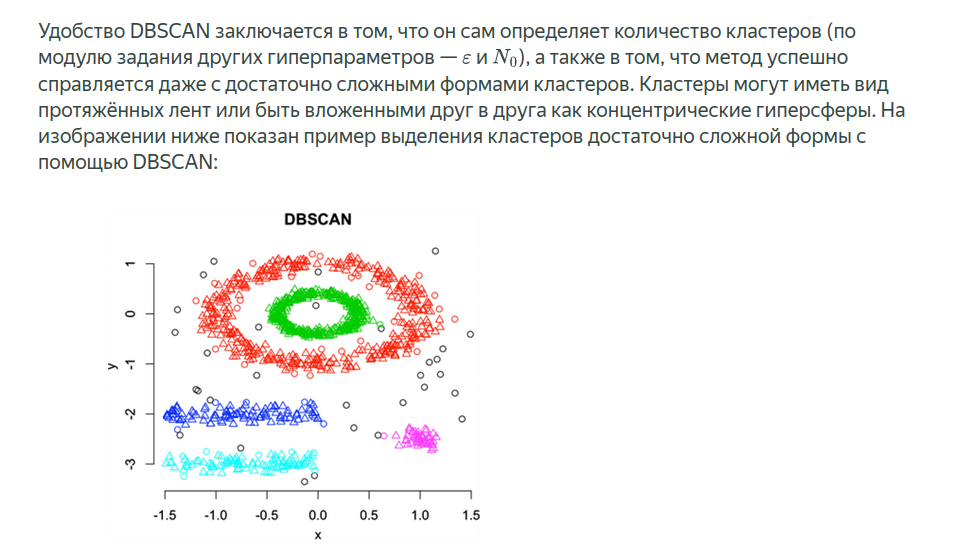

## Agglomerative & division clustering

В случае иерархической агломеративной кластеризации мы действительно будем начинать с кластеров из одного объекта, постепенно объединяя их, а уже последовательность этих объединений даст структуру вложенности кластеров. Даже если в итоге мы будем использовать кластеры с одного уровня, не углубляясь ни в какую вложенность, кластеризация всё равно называется иерархической, так как иерархия естественным образом возникает в процессе работы алгоритма.

Сам алгоритм выглядит предельно просто:

1. Создаём столько кластеров, сколько у нас объектов в выборке, каждый объект — в своём отдельном кластере.
2. Повторяем итеративно слияние двух ближайших кластеров, пока не выполнится критерий останова.

Дивизивные начинают с больших кластеров (обычно – с одного единственного кластера) и постепенно делят на кластеры поменьше.

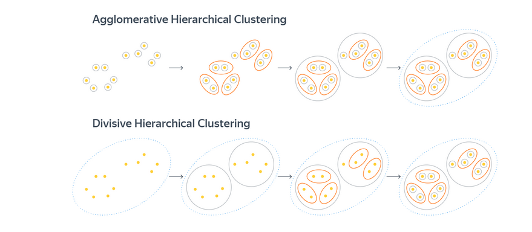

**Подсчёт расстояния**

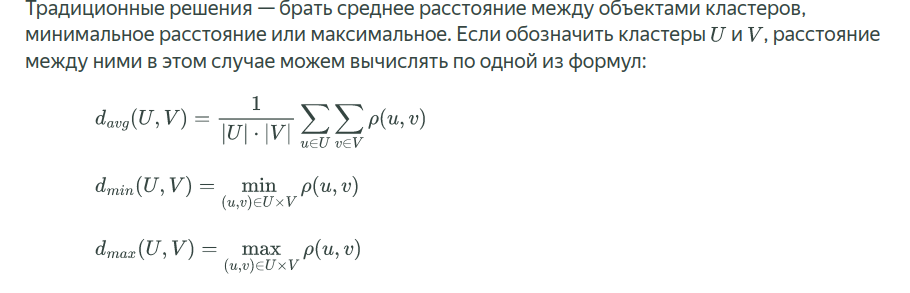

**Критерий останова**

1. Нужно кол-во кластеров
2. Сильное изменение расстояний после шага итерации

# Метрики оценки алгоритмов кластеризации

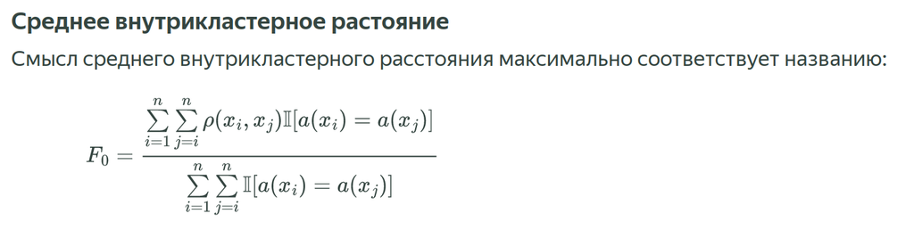

Минимизируем т.к. хотим более кучные кластеры

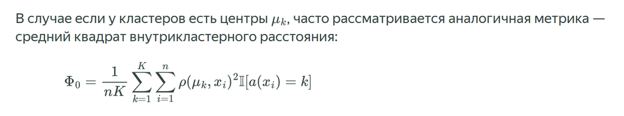

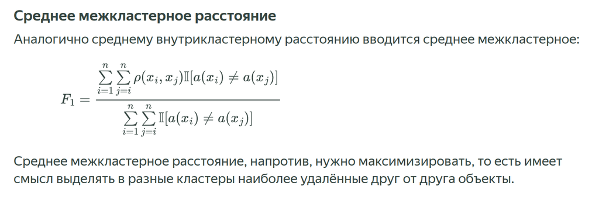